# Copy of NLP_Project_Full_Code (1)

## **Problem Statement**

### Business Context

The prices of the stocks of companies listed under a global exchange are influenced by a variety of factors, with the company's financial performance, innovations and collaborations, and market sentiment being factors that play a significant role. News and media reports can rapidly affect investor perceptions and, consequently, stock prices in the highly competitive financial industry. With the sheer volume of news and opinions from a wide variety of sources, investors and financial analysts often struggle to stay updated and accurately interpret its impact on the market. As a result, investment firms need sophisticated tools to analyze market sentiment and integrate this information into their investment strategies.

### Problem Definition

With an ever-rising number of news articles and opinions, an investment startup aims to leverage artificial intelligence to address the challenge of interpreting stock-related news and its impact on stock prices. They have collected historical daily news for a specific company listed under NASDAQ, along with data on its daily stock price and trade volumes.

As a member of the Data Science and AI team in the startup, you have been tasked with analyzing the data, developing an AI-driven sentiment analysis system that will automatically process and analyze news articles to gauge market sentiment, and summarizing the news at a weekly level to enhance the accuracy of their stock price predictions and optimize investment strategies. This will empower their financial analysts with actionable insights, leading to more informed investment decisions and improved client outcomes.

### Data Dictionary

- `Date` : The date the news was released
- `News` : The content of news articles that could potentially affect the company's stock price
- `Open` : The stock price (in \$) at the beginning of the day
- `High` : The highest stock price (in \$) reached during the day
- `Low` : The lowest stock price (in \$) reached during the day
- `Close` : The adjusted stock price (in \$) at the end of the day
- `Volume` : The number of shares traded during the day
- `Label` : The sentiment polarity of the news content
  - 1: positive
  - 0: neutral
  - -1: negative

## **Installing and Importing Necessary Libraries**

```python
# installing the sentence-transformers and gensim libraries for word embeddings
!pip install -U sentence-transformers gensim transformers tqdm -q
```

```
     ━━━━━━━━━━━━━━━━━━━━━━━━━━━━━━━━━━━━━━━━ 44.1/44.1 kB 2.2 MB/s eta 0:00:00
   ━━━━━━━━━━━━━━━━━━━━━━━━━━━━━━━━━━━━━━━━ 255.8/255.8 kB 7.9 MB/s eta 0:00:00
   ━━━━━━━━━━━━━━━━━━━━━━━━━━━━━━━━━━━━━━━━ 10.0/10.0 MB 53.5 MB/s eta 0:00:00
   ━━━━━━━━━━━━━━━━━━━━━━━━━━━━━━━━━━━━━━━━ 3.0/3.0 MB 28.4 MB/s eta 0:00:00
```

```python
# To manipulate and analyze data
import pandas as pd
import numpy as np

# To visualize data
import matplotlib.pyplot as plt
import seaborn as sns

# To used time-related functions
import time

# to use regular expressions for manipulating text data
import re

# to load the natural language toolkit
import nltk
nltk.download('stopwords')    # loading the stopwords
nltk.download('wordnet')    # loading the wordnet module that is used in stemming

# to remove common stop words
from nltk.corpus import stopwords

# to perform stemming
from nltk.stem.porter import PorterStemmer

# To encode the target variable
from sklearn.preprocessing import LabelEncoder

# To import Word2Vec
from gensim.models import Word2Vec

# To tune the model
from sklearn.model_selection import GridSearchCV

# Converting the Stanford GloVe model vector format to word2vec
from gensim.scripts.glove2word2vec import glove2word2vec
from gensim.models import KeyedVectors

# To split data into train and test sets
from sklearn.model_selection import train_test_split


# To parse JSON data
import json

# To build, tune, and evaluate ML models
from sklearn.tree import DecisionTreeClassifier # Changed import statement to import from sklearn.tree
from sklearn.ensemble import GradientBoostingClassifier
from sklearn.ensemble import RandomForestClassifier


from sklearn.model_selection import GridSearchCV
from sklearn.metrics import confusion_matrix, accuracy_score, f1_score, precision_score, recall_score

# To load/create word embeddings
from gensim.models import Word2Vec
from gensim.models import KeyedVectors
from gensim.scripts.glove2word2vec import glove2word2vec

# To work with transformer models
import torch
from sentence_transformers import SentenceTransformer

# To implement progress bar related functionalities
from tqdm import tqdm
tqdm.pandas()

# To ignore unnecessary warnings
import warnings
warnings.filterwarnings('ignore')
```

## **Loading the dataset**

```python
from google.colab import drive
drive.mount('/content/drive')
```

```python
news = pd.read_csv("/content/drive/MyDrive/NLP Project/stock_news.csv")
```

```python
data = news.copy()
```

## **Data Overview**

```python
# Print first 5 rows of data
data.head()
```

|  | Date | News | Open | High | Low | Close | Volume | Label |
| --- | --- | --- | --- | --- | --- | --- | --- | --- |
| 0 | 2019-01-02 | The tech sector experienced a significant dec... | 41.740002 | 42.244999 | 41.482498 | 40.246914 | 130672400 | -1 |
| 1 | 2019-01-02 | Apple lowered its fiscal Q1 revenue guidance ... | 41.740002 | 42.244999 | 41.482498 | 40.246914 | 130672400 | -1 |
| 2 | 2019-01-02 | Apple cut its fiscal first quarter revenue fo... | 41.740002 | 42.244999 | 41.482498 | 40.246914 | 130672400 | -1 |
| 3 | 2019-01-02 | This news article reports that yields on long... | 41.740002 | 42.244999 | 41.482498 | 40.246914 | 130672400 | -1 |
| 4 | 2019-01-02 | Apple's revenue warning led to a decline in U... | 41.740002 | 42.244999 | 41.482498 | 40.246914 | 130672400 | -1 |

```python
#Checking the news
data.loc[0,'News']
```

```
" The tech sector experienced a significant decline in the aftermarket following Apple's Q1 revenue warning. Notable suppliers, including Skyworks, Broadcom, Lumentum, Qorvo, and TSMC, saw their stocks drop in response to Apple's downward revision of its revenue expectations for the quarter, previou…
```

```python
# Print last 5 rows of data
data.tail()
```

|  | Date | News | Open | High | Low | Close | Volume | Label |
| --- | --- | --- | --- | --- | --- | --- | --- | --- |
| 344 | 2019-04-30 | Media mogul Oprah Winfrey, known for influenc... | 50.764999 | 50.849998 | 49.7775 | 48.70879 | 186139600 | -1 |
| 345 | 2019-04-30 | European shares fell on Tuesday, with banks u... | 50.764999 | 50.849998 | 49.7775 | 48.70879 | 186139600 | -1 |
| 346 | 2019-04-30 | This article reports that the S&P 500 reached... | 50.764999 | 50.849998 | 49.7775 | 48.70879 | 186139600 | -1 |
| 347 | 2019-04-30 | The Federal Reserve is anticipated to keep in... | 50.764999 | 50.849998 | 49.7775 | 48.70879 | 186139600 | -1 |
| 348 | 2019-04-30 | In the first quarter, South Korea's Samsung E... | 50.764999 | 50.849998 | 49.7775 | 48.70879 | 186139600 | 0 |

### Checking the shape of the dataset

```python
# print shape of data
data.shape
```

```
(349, 8)
```

There are 349 rows and 8 columns(parameters) for this data

### Checking for missing values

```python
# Check for missing values
data.isnull().sum()
```

|  | 0 |
| --- | --- |
| Date | 0 |
| News | 0 |
| Open | 0 |
| High | 0 |
| Low | 0 |
| Close | 0 |
| Volume | 0 |
| Label | 0 |

**dtype:** int64

There are no missing values

### Checking for duplicate values

```python
# Check for duplicate values
data.duplicated().sum()
```

```
0
```

No Duplicates in the data

### Checking the statistical summary

```python
data.describe()
```

|  | Open | High | Low | Close | Volume | Label |
| --- | --- | --- | --- | --- | --- | --- |
| count | 349.000000 | 349.000000 | 349.000000 | 349.000000 | 3.490000e+02 | 349.000000 |
| mean | 46.229233 | 46.700458 | 45.745394 | 44.926317 | 1.289482e+08 | -0.054441 |
| std | 6.442817 | 6.507321 | 6.391976 | 6.398338 | 4.317031e+07 | 0.715119 |
| min | 37.567501 | 37.817501 | 37.305000 | 36.254131 | 4.544800e+07 | -1.000000 |
| 25% | 41.740002 | 42.244999 | 41.482498 | 40.246914 | 1.032720e+08 | -1.000000 |
| 50% | 45.974998 | 46.025002 | 45.639999 | 44.596924 | 1.156272e+08 | 0.000000 |
| 75% | 50.707500 | 50.849998 | 49.777500 | 49.110790 | 1.511252e+08 | 0.000000 |
| max | 66.817497 | 67.062500 | 65.862503 | 64.805229 | 2.444392e+08 | 1.000000 |

## **Exploratory Data Analysis**

### Univariate Analysis

- Distribution of individual variables
- Compute and check the distribution of the length of news content

#### Distribution of article categories

```python
# function to create labeled barplots

def labeled_barplot(data, feature, perc=False, n=None):
    """
    Barplot with percentage at the top

    data: dataframe
    feature: dataframe column
    perc: whether to display percentages instead of count (default is False)
    n: displays the top n category levels (default is None, i.e., display all levels)
    """

    total = len(data[feature])  # length of the column
    count = data[feature].nunique()
    if n is None:
        plt.figure(figsize=(count + 1, 5))
    else:
        plt.figure(figsize=(n + 1, 5))

    plt.xticks(rotation=90, fontsize=15)
    ax = sns.countplot(
        data=data,
        x=feature,
        palette="Paired",
        order=data[feature].value_counts().index[:n].sort_values(),
    )

    for p in ax.patches:
        if perc == True:
            label = "{:.1f}%".format(
                100 * p.get_height() / total
            )  # percentage of each class of the category
        else:
            label = p.get_height()  # count of each level of the category

        x = p.get_x() + p.get_width() / 2  # width of the plot
        y = p.get_height()  # height of the plot

        ax.annotate(
            label,
            (x, y),
            ha="center",
            va="center",
            size=12,
            xytext=(0, 5),
            textcoords="offset points",
        )  # annotate the percentage

    plt.show()  # show the plot
```

#### Distribution of Label categories

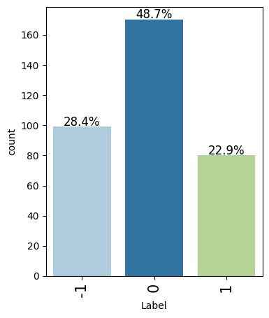

```python
labeled_barplot(data, "Label", perc=True)
```

Graph shows that 48.7% of data have Neutral Sentiment.

28.4 % have Negavtive Sentiment and 22.9 % have Positive Sentiment.

#### Density Plot of Price - Open

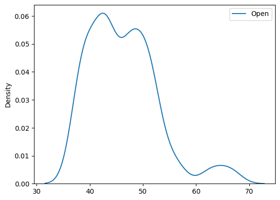

```python
sns.kdeplot(data[['Open']],palette="tab10");
```

Density plot shows that most of the Opening value is between 40 and 50

#### Density Plot of Price - Low

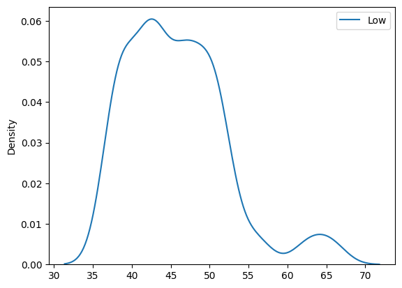

```python
sns.kdeplot(data[['Low']], palette="tab10");
```

Density plot shows that most of the Low value is between 40 and 50

#### Density Plot of Price - High

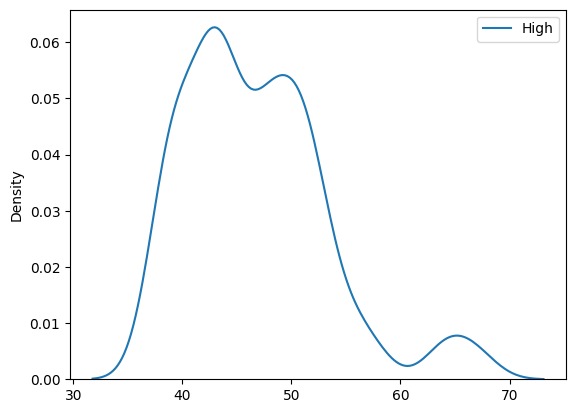

```python
sns.kdeplot(data[['High']],  palette="tab10");
```

Density plot shows that most of the High value is between 40 and 50

#### Density Plot of Price - Close

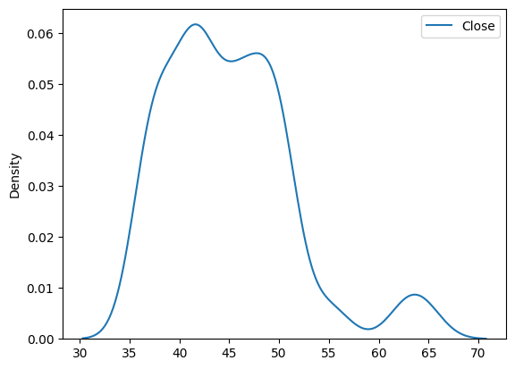

```python
sns.kdeplot(data[['Close']], palette="tab10");
```

Most closing values are between 40 and 50

Plotting Volume

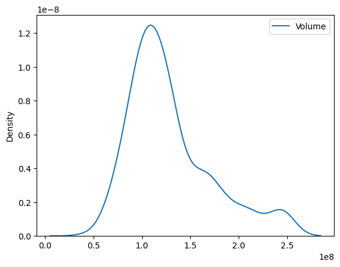

```python
sns.kdeplot(data[['Volume']], palette="tab10");
```

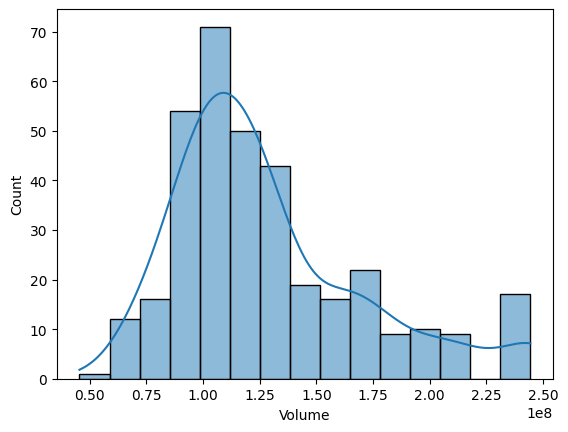

```python
sns.histplot(data, x='Volume',kde = True);
```

Volume distribution peaks at 1.1

Distribution is very slightly right skewed

### Compute and check the distribution of the length of news content

```python
# Use split() to get words in the News as a list and store it as a new data parameter
data['news_length'] = data['News'].apply(lambda x: len(x.split(" ")))

data.head()
```

|  | Date | News | Open | High | Low | Close | Volume | Label | news_length |
| --- | --- | --- | --- | --- | --- | --- | --- | --- | --- |
| 0 | 2019-01-02 | The tech sector experienced a significant dec... | 41.740002 | 42.244999 | 41.482498 | 40.246914 | 130672400 | -1 | 46 |
| 1 | 2019-01-02 | Apple lowered its fiscal Q1 revenue guidance ... | 41.740002 | 42.244999 | 41.482498 | 40.246914 | 130672400 | -1 | 51 |
| 2 | 2019-01-02 | Apple cut its fiscal first quarter revenue fo... | 41.740002 | 42.244999 | 41.482498 | 40.246914 | 130672400 | -1 | 49 |
| 3 | 2019-01-02 | This news article reports that yields on long... | 41.740002 | 42.244999 | 41.482498 | 40.246914 | 130672400 | -1 | 51 |
| 4 | 2019-01-02 | Apple's revenue warning led to a decline in U... | 41.740002 | 42.244999 | 41.482498 | 40.246914 | 130672400 | -1 | 50 |

Analyzing the distribution of news length

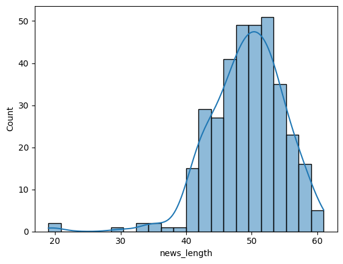

```python
sns.histplot(data, x='news_length',kde = True);
```

News Length is left skewed. Length vairs from 20 to 60.

Most of the news are between length 50.

### Bivariate Analysis

- Correlation
- Sentiment Polarity vs Price
- Date vs Price

**Note**: The above points are listed to provide guidance on how to approach bivariate analysis. Analysis has to be done beyond the above listed points to get maximum scores.

#### Heat Map

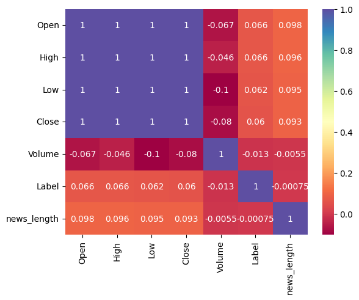

```python
# Heatmap for numercial columns
sns.heatmap(data[data.columns[2:]].corr(),annot=True,cmap="Spectral");
```

We Notice that Open, High, Low and Close have full correlation with each other.

We dont see any good correlation with Label, Volume or news length.

#### Label Vs Open

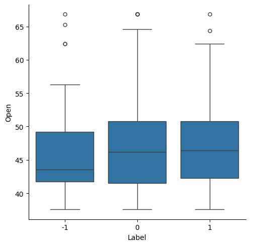

```python
# Plot rleation between Label and Open
sns.catplot(x="Label", y="Open", kind="box", data=data);
```

We see that as Opening value is high, there is a Neutral or Positive sentiment.

When the opening value is below 43, there is more chance of Negative sentiment

There are outliers in the data

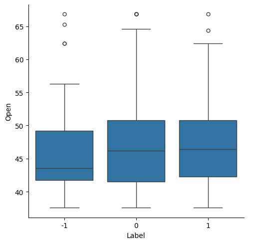

```python
# Plot rleation between Label and Close
sns.catplot(x="Label", y="Open", kind="box", data=data);
```

There are outliers in the data.

#### Label Vs High

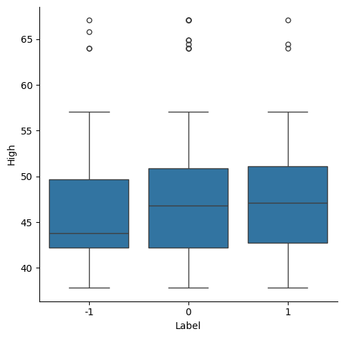

```python
# Plot rleation between Label and High
sns.catplot(x="Label", y="High", kind="box", data=data);
```

As the High value increases, there is a tendency for Positive Setiment.

There are outliers in the data.

#### Label Vs Low

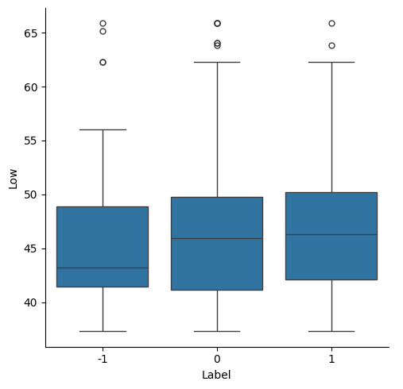

```python
# Plot rleation between Label and Low
sns.catplot(x="Label", y="Low", kind="box", data=data);
```

Higher the Low value, we see the Sentiment moves towards Neutral and Positive.

There are outliers in the data

#### Label Vs Volume

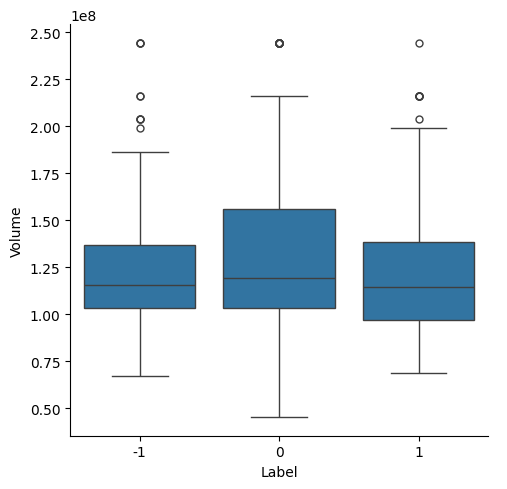

```python
# Plot rleation between Label and Volume
sns.catplot(x="Label", y="Volume", kind="box", data=data);
```

Positive sentiment and Negavtive sentiment is observed when the Volume is low. As Volume of stocks increases, there is a tendency for Neutral sentiment.

## **Data Preprocessing**

We will do preprocessing of the data to split into Train, Test and Validation.

The goal is comeup with a model which can be used to predict the Sentiment by training with the train data.

Here we will start with processing the data. The Use Word2Vec, GloVe and Sentence Transformer to embed the News column of the data.

We will use this embedded text as the input to a Random Classifier and check the Accuracy, Precision, Recall and F1 Score.

We will also perform GridSearch CV and Hyper parameter tuning to Random Forest Classifier to check if we can get better results.

We will finalize a model with the best mterics.

### Train-test-validation Split

```python
#Complete the code to print the statistical summary of the 'Date' column
data['Date'].describe()
```

|  | Date |
| --- | --- |
| count | 349 |
| unique | 71 |
| top | 2019-01-03 |
| freq | 28 |

**dtype:** object

```python
# find min, max and mean in Date column
# Convert the 'date' column to datetime format with yyyy-mm-dd format
data['Date'] = pd.to_datetime(data['Date'], format='%Y-%m-%d')
print("Min date is ",data['Date'].min())
print("Max date is ",data['Date'].max())
print("Mean date is ",data['Date'].mean())
```

```
Min date is  2019-01-02 00:00:00
Max date is  2019-04-30 00:00:00
Mean date is  2019-02-16 16:05:30.085959936
```

```python
X = data.drop('Label', axis=1)
y = data['Label']
```

```python
stock = data.copy()
```

```python
X_train = stock[(stock['Date'] < '2019-04-01')].reset_index()    #Complete the code to select all rows where the 'Date' is before '2019-04-01'
X_val = stock[(stock['Date'] >= '2019-04-01') & (stock['Date'] < '2019-04-16')].reset_index()    #Complete the code to select all rows where the 'Date' is from '2019-04-01 to '2019-04-16' (excluded)
X_test = stock[stock['Date'] >= '2019-04-16'].reset_index()
```

```python
# Complete the code to pick the 'Label' column as the target variable
y_train = X_train["Label"].copy()
y_val = X_val["Label"].copy()
y_test = X_test["Label"].copy()
```

```python
#Complete the code to print the shape of X_train,X_val,X_test,y_train,y_val and y_test
print("Train data shape",X_train.shape)
print("Validation data shape",X_val.shape)
print("Test data shape ",X_test.shape)

print("Train label shape",y_train.shape)
print("Validation label shape",y_val.shape)
print("Test label shape ",y_test.shape)
```

```
Train data shape (286, 10)
Validation data shape (21, 10)
Test data shape  (42, 10)
Train label shape (286,)
Validation label shape (21,)
Test label shape  (42,)
```

#### **Preprocessing the textual column**

```python
dataset = data.copy()
```

```python
# Loading the Porter Stemmer
ps = PorterStemmer()
```

```python
def preprocess_text(text):
    # Convert to lowercase
    text = text.lower()

    # Remove special characters and numbers
    text = re.sub(r'[^A-Za-z\s]', '', text)

    # Remove extra whitespaces
    text = re.sub(r'\s+', ' ', text).strip()

    # Split text into separate words
    words = text.split()

    # Removing English language stopwords
    text = ' '.join([word for word in words if word not in stopwords.words('english')])

    # Applying the Porter Stemmer on every word of a message and joining the stemmed words back into a single string
    text = ' '.join([ps.stem(word) for word in words])

    return text
```

```python
# preprocessing the textual column
dataset['Article_text_clean'] = dataset['News'].apply(preprocess_text)
```

## **Word Embeddings**

### **Word2Vec**

```python
# Creating a list of all words in our data
words_list = [item.split(" ") for item in dataset['Article_text_clean'].values]
```

```python
# Creating an instance of Word2Vec
vec_size = 300
model_W2V = Word2Vec(words_list, vector_size = vec_size, min_count = 1, window=5, workers = 6)
```

```python
# Checking the size of the vocabulary
print("Length of the vocabulary is", len(list(model_W2V.wv.key_to_index)))
```

```
Length of the vocabulary is 2595
```

```python
# Checking the word embedding of a random word
word = "sector"
model_W2V.wv[word]
```

```
array([-0.02781967,  0.07547101,  0.00668657,  0.02132647, -0.00606414,
       -0.07078025,  0.03943259,  0.17246126,  0.01878256, -0.0373769 ,
        0.00155433, -0.05943137,  0.01564027, -0.00643856, -0.06593764,
       -0.06747353,  0.04435833, -0.00308428,  0.005475  , -0.03020513,
       -0.04061944,  0.00329643,  0.07759658,  0.0167664 ,  0.05607389,
        0.00987318, -0.09782211,  0.02760131, -0.03570256, -0.07151962,
        0.00312357, -0.02135698,  0.02228168, -0.01702967, -0.00839627,
        0.02810812,  0.05225183, -0.0949789 , -0.00615296,  0.008517  ,
       -0.04250454,  0.00236664,  0.01392311, -0.06089744,  0.03155078,
        0.05461871,  0.0207498 ,  0.03061671, -0.00357885,  0.06397041,
        0.02476566,  0.01373913, -0.03335772,  0.00893135, -0.00461316,
        0.08797535,  0.03691512,  0.00706342,  0.02565064, -0.00559152,
       -0.03724815, -0.0056    ,  0.01613901,  0.00797749,  0.01810279,
        0.04091051,  0.02448271,  0.03498534, -0.04222263, -0.02155677,
        0.02434453,  0.04080109,  0.06833837, -0.04885645,  0.02094629,
        0.04811944, -0.07140433,  0.00584952, -0.02949656,  0.06967719,
       -0.03581676, -0.05442135,  0.00777028,  0.15353116,  0.02342005,
        0.00946549, -0.02585411,  0.0142316 ,  0.07398165,  0.0329538 ,
        0.08132424, -0.03636937,  0.02877474, -0.01374586,  0.09460458,
        0.07398879,  0.06875797, -0.03705655, -0.03904901,  0.05680866,
       -0.02064127,  0.01559346,  0.06176382,  0.02445866,  0.01854266,
       -0.0462094 , -0.01773761,  0.01924691, -0.06840125,  0.01927425,
       -0.09842077, -0.01610275, -0.00482562,  0.05203386,  0.02785318,
        0.01945201, -0.01477756, -0.00019673,  0.07286622, -0.11036001,
        0.03685449,  0.06234451,  0.0459253 ,  0.03024182, -0.02951698,
        0.03728125,  0.02151647, -0.0577206 , -0.00281997,  0.07000111,
        0.04238607,  0.08599326,  0.03001227, -0.07888693,  0.04421949,
        0.04869265, -0.0181658 , -0.01940063, -0.06400762, -0.08491933,
        0.01181896, -0.09216951, -0.02196592,  0.06487848,  0.04569127,
       -0.03386437, -0.08645616, -0.02743307,  0.04762466, -0.04667431,
        0.01456785, -0.1231651 , -0.04884144, -0.04662462,  0.00402273,
        0.04019308, -0.0557396 , -0.07405679, -0.01223782,  0.08546404,
        0.00874018,  0.04768757, -0.08969119,  0.06465576, -0.04557189,
        0.02333054,  0.03000353,  0.01601587,  0.0107943 ,  0.12836841,
       -0.04162608,  0.01527034,  0.02380524,  0.02814075, -0.00212703,
        0.02819618, -0.00581685, -0.06649845, -0.00024873, -0.01136522,
       -0.03144359,  0.02536131, -0.04793199, -0.03089677, -0.04476797,
       -0.00219269,  0.09162468,  0.08507013,  0.01189359, -0.08112168,
        0.03722779, -0.00725827, -0.07154799,  0.02133946,  0.03002363,
       -0.0770752 ,  0.00625416, -0.06743751,  0.03808305,  0.00318489,
       -0.0607423 ,  0.03211474,  0.00819862, -0.05407068, -0.00839256,
       -0.00809047, -0.00439322,  0.03794721, -0.00605157, -0.00911547,
        0.01887139, -0.06838696, -0.03331514, -0.04317967,  0.03284172,
       -0.0627277 , -0.03245874, -0.14164166, -0.09026915, -0.08460649,
        0.05313317,  0.0138503 , -0.0519919 , -0.04697232, -0.06763645,
       -0.03243431,  0.00571504, -0.01339563, -0.05520247,  0.03055879,
        0.04990876, -0.03919905, -0.03285875,  0.03412814, -0.04109299,
        0.03076166, -0.01044883,  0.02571972,  0.0214047 , -0.11014231,
        0.02157955, -0.04328516, -0.03658139, -0.00206691,  0.01824508,
       -0.0757521 , -0.00820371,  0.01773873,  0.01041395,  0.04855928,
        0.05053255,  0.00701189,  0.03283614,  0.00733751, -0.08615114,
       -0.0290618 ,  0.11224265,  0.00998255, -0.12145841, -0.05838514,
        0.03239834,  0.03322425,  0.02313993, -0.10907762, -0.0760259 ,
       -0.00770404,  0.01675406,  0.05395229, -0.05656086,  0.00130151,
       -0.04911672,  0.0071139 ,  0.00391236, -0.03074099,  0.07778922,
        0.01943525,  0.07350516,  0.01362724, -0.07074466, -0.00248756,
        0.03411596,  0.00269394, -0.02054671,  0.00537319,  0.01670791,
        0.01418725, -0.08781979,  0.0575608 ,  0.01524155,  0.05612849,
        0.03121554,  0.09473423,  0.06148698,  0.02736075,  0.10324411,
        0.09183966,  0.01277985, -0.05016292,  0.06256302, -0.03413111],
      dtype=float32)
```

```python
# Retrieving the words present in the Word2Vec model's vocabulary
words = list(model_W2V.wv.key_to_index.keys())

# Retrieving word vectors for all the words present in the model's vocabulary
wvs = model_W2V.wv[words].tolist()

# Creating a dictionary of words and their corresponding vectors
word_vector_dict = dict(zip(words, wvs))
```

```python
def average_vectorizer_Word2Vec(doc):
    # Initializing a feature vector for the sentence
    feature_vector = np.zeros((vec_size,), dtype="float64")

    # Creating a list of words in the sentence that are present in the model vocabulary
    words_in_vocab = [word for word in doc.split() if word in words]

    # adding the vector representations of the words
    for word in words_in_vocab:
        feature_vector += np.array(word_vector_dict[word])

    # Dividing by the number of words to get the average vector
    if len(words_in_vocab) != 0:
        feature_vector /= len(words_in_vocab)

    return feature_vector
```

```python
# creating a dataframe of the vectorized documents
start = time.time()

X_train_wv = pd.DataFrame(X_train["News"].apply(average_vectorizer_Word2Vec).tolist(), columns=['Feature '+str(i) for i in range(vec_size)])
X_val_wv = pd.DataFrame(X_val["News"].apply(average_vectorizer_Word2Vec).tolist(), columns=['Feature '+str(i) for i in range(vec_size)])
X_test_wv = pd.DataFrame(X_test["News"].apply(average_vectorizer_Word2Vec).tolist(), columns=['Feature '+str(i) for i in range(vec_size)])

end = time.time()
print('Time taken ', (end-start))
```

```
Time taken  0.5938050746917725
```

```python
print(X_train_wv.shape, X_val_wv.shape, X_test_wv.shape)
```

```
(286, 300) (21, 300) (42, 300)
```

### GloVe

```python
# load the Stanford GloVe model
filename = '/content/drive/MyDrive/NLP Project/glove.6B.100d.txt.word2vec'
glove_model = KeyedVectors.load_word2vec_format(filename, binary=False)
```

```python
# Checking the size of the vocabulary
print("Length of the vocabulary is", len(glove_model.index_to_key))
```

```
Length of the vocabulary is 400000
```

Let's check out a few word embeddings.

```python
# Checking the word embedding of a random word
word = "sector"
glove_model[word]
```

```
array([-0.21739 ,  0.33174 , -0.22599 ,  0.42469 , -0.11928 , -1.3952  ,
       -0.61638 ,  0.16532 ,  0.70989 , -0.061456,  0.26858 , -0.72516 ,
        0.22991 , -0.16301 , -0.34453 , -0.33406 ,  0.05817 , -0.1685  ,
        0.1737  ,  0.51392 ,  0.44451 ,  0.064872, -0.052846,  0.25639 ,
       -0.66442 , -0.94907 ,  0.12682 ,  0.025997, -0.68997 , -0.037575,
       -0.27894 ,  0.011533,  0.1049  , -0.71057 , -0.32381 , -0.052246,
        0.24593 ,  0.13478 , -0.44602 , -0.22216 ,  0.029992, -0.8204  ,
        0.048683,  0.43101 ,  0.43145 , -0.41937 ,  0.195   ,  1.001   ,
       -0.40675 , -1.1748  , -1.0851  ,  0.52076 , -0.46837 ,  1.1032  ,
       -0.16561 , -1.341   , -0.21264 , -0.6057  ,  1.995   ,  0.59525 ,
        0.24307 , -0.75293 , -0.59347 ,  0.058302,  0.12146 ,  0.64771 ,
        0.27476 , -0.47577 ,  1.2488  ,  0.031337,  0.73221 , -0.015229,
       -0.64309 , -0.45713 ,  0.30611 , -0.24862 , -0.21978 ,  0.46051 ,
       -0.57377 , -0.2312  ,  1.14    ,  0.48758 , -0.5097  ,  0.10044 ,
       -1.2822  , -0.36468 , -0.15005 , -0.56855 ,  0.075334, -0.54233 ,
        0.52299 , -0.21303 , -0.4815  , -0.31234 , -0.27282 ,  1.4918  ,
        0.55346 , -0.30467 ,  0.8394  ,  0.27971 ], dtype=float32)
```

```python
# Retrieving the words present in the GloVe model's vocabulary
glove_words = glove_model.index_to_key

# Creating a dictionary of words and their corresponding vectors
glove_word_vector_dict = dict(zip(glove_model.index_to_key,list(glove_model.vectors)))
```

```python
vec_size=100
```

```python
def average_vectorizer_GloVe(doc):
    # Initializing a feature vector for the sentence
    feature_vector = np.zeros((vec_size,), dtype="float64")

    # Creating a list of words in the sentence that are present in the model vocabulary
    words_in_vocab = [word for word in doc.split() if word in glove_words]

    # adding the vector representations of the words
    for word in words_in_vocab:
        feature_vector += np.array(glove_word_vector_dict[word])

    # Dividing by the number of words to get the average vector
    if len(words_in_vocab) != 0:
        feature_vector /= len(words_in_vocab)

    return feature_vector
```

```python
# creating a dataframe of the vectorized documents
start = time.time()

X_train_gl = pd.DataFrame(X_train["News"].apply(average_vectorizer_GloVe).tolist(), columns=['Feature '+str(i) for i in range(vec_size)]) #Apply GloVe on 'News' column
X_val_gl = pd.DataFrame(X_val["News"].apply(average_vectorizer_GloVe).tolist(), columns=['Feature '+str(i) for i in range(vec_size)]) #Apply GloVe on 'News' column
X_test_gl = pd.DataFrame(X_test["News"].apply(average_vectorizer_GloVe).tolist(), columns=['Feature '+str(i) for i in range(vec_size)]) #Apply GloVe on 'News' column

end = time.time()
print('Time taken ', (end-start))
```

```
Time taken  29.47978663444519
```

```python
print(X_train_gl.shape, X_val_gl.shape, X_test_gl.shape)
```

```
(286, 100) (21, 100) (42, 100)
```

### Sentence Transformer

#### Defining the model

```python
#Defining the model
model = SentenceTransformer('sentence-transformers/all-MiniLM-L6-v2')
```

#### Encoding the dataset

```python
# setting the device to GPU if available, else CPU
device = torch.device("cuda" if torch.cuda.is_available() else "cpu")
```

```python
# encoding the dataset
start = time.time()

X_train_st = model.encode(X_train["News"].values, show_progress_bar=True, device=device) #Apply Sentence Transformer on 'News' column
X_val_st = model.encode(X_val["News"].values, show_progress_bar=True, device=device) #Apply Sentence Transformer on 'News' column
X_test_st = model.encode(X_test["News"].values, show_progress_bar=True, device=device) #Apply Sentence Transformer on 'News' column

end = time.time()
print("Time taken ",(end-start))
```

```
Time taken  1.6345267295837402
```

```python
#print the shape
print(X_train_st.shape, X_val_st.shape, X_test_st.shape)
```

```
(286, 384) (21, 384) (42, 384)
```

## **Sentiment Analysis**

### Utility Functions

```python
def plot_confusion_matrix(model, predictors, target):
    """
    Plot a confusion matrix to visualize the performance of a classification model.

    Parameters:
    actual (array-like): The true labels.
    predicted (array-like): The predicted labels from the model.

    Returns:
    None: Displays the confusion matrix plot.
    """
    pred = model.predict(predictors)  # Make predictions using the classifier.

    cm = confusion_matrix(target, pred)  # Compute the confusion matrix.

    plt.figure(figsize=(5, 4))  # Create a new figure with a specified size.
    label_list = [0, 1,-1]  # Define the labels for the confusion matrix.
    sns.heatmap(cm, annot=True, fmt='.0f', cmap='Blues', xticklabels=label_list, yticklabels=label_list)
    # Plot the confusion matrix using a heatmap with annotations.

    plt.ylabel('Actual')  # Label for the y-axis.
    plt.xlabel('Predicted')  # Label for the x-axis.
    plt.title('Confusion Matrix')  # Title of the plot.
    plt.show()  # Display the plot.
```

```python
# defining a function to compute different metrics to check performance of a classification model built using sklearn
def model_performance_classification_sklearn(model, predictors, target):
    """
    Function to compute different metrics to check classification model performance

    model: classifier
    predictors: independent variables
    target: dependent variable
    """

    # predicting using the independent variables
    pred = model.predict(predictors)

    acc = accuracy_score(target, pred)  # to compute Accuracy
    recall = recall_score(target, pred, average='weighted')  # to compute Recall
    precision = precision_score(target, pred, average='weighted')  # to compute Precision
    f1 = f1_score(target, pred, average='weighted')  # to compute F1-score

    # creating a dataframe of metrics
    df_perf = pd.DataFrame(
        {
            "Accuracy": acc,
            "Recall": recall,
            "Precision": precision,
            "F1": f1,
        },
        index=[0],
    )

    return df_perf
```

### RandomForest - Word2Vec

```python
#Building RandomForest classifier
base_wv = RandomForestClassifier(n_estimators=100, random_state=42)
base_wv.fit(X_train_wv, y_train)
```

```
RandomForestClassifier(random_state=42)
```

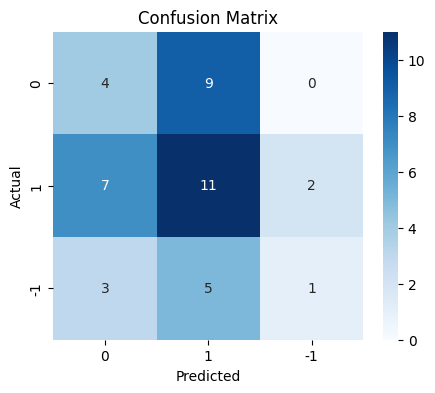

```python
# plot confusion matrix for test data
plot_confusion_matrix(base_wv, X_test_wv, y_test)
```

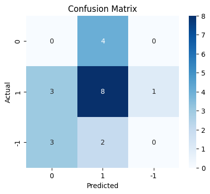

```python
#plot confusion matrix for validation data
plot_confusion_matrix(base_wv, X_val_wv, y_val)
```

```python
# calculate metrics on train data
base_train_wv = model_performance_classification_sklearn(base_wv, X_train_wv, y_train)
base_train_wv
```

|  | Accuracy | Recall | Precision | F1 |
| --- | --- | --- | --- | --- |
| 0 | 1.0 | 1.0 | 1.0 | 1.0 |

```python
# calculate metrics on validation data
base_val_wv = model_performance_classification_sklearn(base_wv, X_val_wv, y_val)
base_val_wv
```

|  | Accuracy | Recall | Precision | F1 |
| --- | --- | --- | --- | --- |
| 0 | 0.380952 | 0.380952 | 0.326531 | 0.351648 |

### RandomForest - GloVe

```python
#build RandomForest for GloVe data
base_gl = RandomForestClassifier(n_estimators=100, random_state=42)
base_gl.fit(X_train_gl, y_train)
```

```
RandomForestClassifier(random_state=42)
```

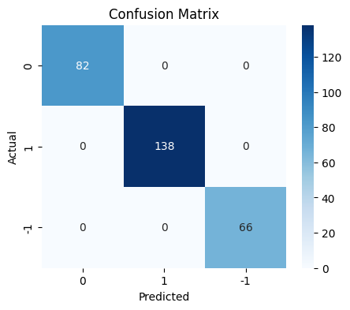

```python
#plot confusion matrix for train data
plot_confusion_matrix(base_gl, X_train_gl, y_train)
```

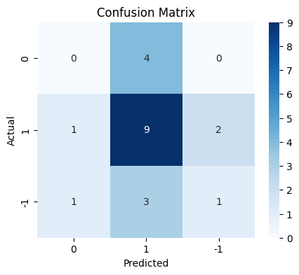

```python
#plot confusion matrix for validation data
plot_confusion_matrix(base_gl, X_val_gl, y_val)
```

```python
#calculate metrics for train data
base_train_gl = model_performance_classification_sklearn(base_gl, X_train_gl, y_train)
base_train_gl
```

|  | Accuracy | Recall | Precision | F1 |
| --- | --- | --- | --- | --- |
| 0 | 1.0 | 1.0 | 1.0 | 1.0 |

```python
#calculate metrics for validation data
base_val_gl = model_performance_classification_sklearn(base_gl, X_val_gl, y_val)
base_val_gl
```

|  | Accuracy | Recall | Precision | F1 |
| --- | --- | --- | --- | --- |
| 0 | 0.47619 | 0.47619 | 0.400794 | 0.426871 |

### Random Forest - Sentence Transformer

```python
# build Random Forest with sentence Tranformer encoded data
base_st = RandomForestClassifier(n_estimators=100, random_state=42)
base_st.fit(X_train_st, y_train)
```

```
RandomForestClassifier(random_state=42)
```

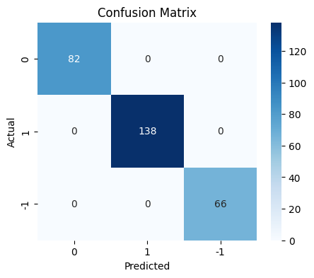

```python
#plot confusion matrix for train data
plot_confusion_matrix(base_st, X_train_st, y_train)
```

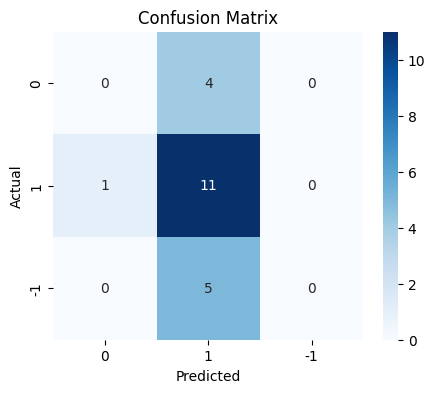

```python
#plot confusion matrix for validation data
plot_confusion_matrix(base_st, X_val_st, y_val)
```

```python
# calculate metrics for train data
base_train_st = model_performance_classification_sklearn(base_st, X_train_st, y_train)
base_train_st
```

|  | Accuracy | Recall | Precision | F1 |
| --- | --- | --- | --- | --- |
| 0 | 1.0 | 1.0 | 1.0 | 1.0 |

```python
#caluclate metrics for validation data
base_val_st = model_performance_classification_sklearn(base_st, X_val_st, y_val)
base_val_st
```

|  | Accuracy | Recall | Precision | F1 |
| --- | --- | --- | --- | --- |
| 0 | 0.52381 | 0.52381 | 0.314286 | 0.392857 |

### Tuned RandomForest - Word2Vec

```python
#tune Random Forest Classifier
tuned_wv = RandomForestClassifier(random_state=42)
parameters = {
    'max_depth': np.arange(3,7),
    'min_samples_split': np.arange(5,12,2),
    'max_features': ['log2', 'sqrt', 0.2, 0.4]
}
# Run the grid search
grid_obj = GridSearchCV(tuned_wv, parameters, scoring='f1_weighted',cv=5,n_jobs=-1)
grid_obj = grid_obj.fit(X_train_wv, y_train)

end = time.time()
print("Time taken ",(end-start))

# Set the clf to the best combination of parameters
tuned_wv = grid_obj.best_estimator_
```

```
Time taken  192.70894646644592
```

```python
#fit best algorithm to the data
tuned_wv.fit(X_train_wv, y_train)
```

```
RandomForestClassifier(max_depth=6, max_features=0.4, min_samples_split=11,
                       random_state=42)
```

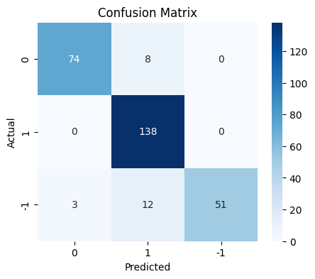

```python
#plot confusion matrix on train data
plot_confusion_matrix(tuned_wv, X_train_wv, y_train)
```

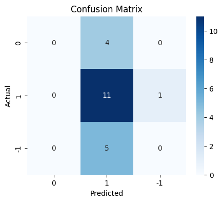

```python
#plot confusion matrix on the validation data
plot_confusion_matrix(tuned_wv, X_val_wv, y_val)
```

```python
#calculate metrics on train data
tuned_train_wv = model_performance_classification_sklearn(tuned_wv, X_train_wv, y_train)
tuned_train_wv
```

|  | Accuracy | Recall | Precision | F1 |
| --- | --- | --- | --- | --- |
| 0 | 0.91958 | 0.91958 | 0.927751 | 0.917976 |

```python
#calculate metrics on validation data
tuned_val_wv = model_performance_classification_sklearn(tuned_wv, X_val_wv, y_val)
tuned_val_wv
```

|  | Accuracy | Recall | Precision | F1 |
| --- | --- | --- | --- | --- |
| 0 | 0.52381 | 0.52381 | 0.314286 | 0.392857 |

### Tuned Random Forest - GloVe

```python
#tune Random Forest Classifier
tuned_gl = RandomForestClassifier(random_state=42)
parameters = {
    'max_depth': np.arange(3,7),
    'min_samples_split': np.arange(5,12,2),
    'max_features': ['log2', 'sqrt', 0.2, 0.4]
}
# Run the grid search
grid_obj = GridSearchCV(tuned_gl, parameters, scoring='f1_weighted',cv=5,n_jobs=-1)
grid_obj = grid_obj.fit(X_train_gl, y_train)

end = time.time()
print("Time taken ",(end-start))

# Set the clf to the best combination of parameters
tuned_gl = grid_obj.best_estimator_
```

```
Time taken  307.04200553894043
```

```python
#fit the tuned model
tuned_gl.fit(X_train_gl, y_train)
```

```
RandomForestClassifier(max_depth=6, max_features=0.2, min_samples_split=7,
                       random_state=42)
```

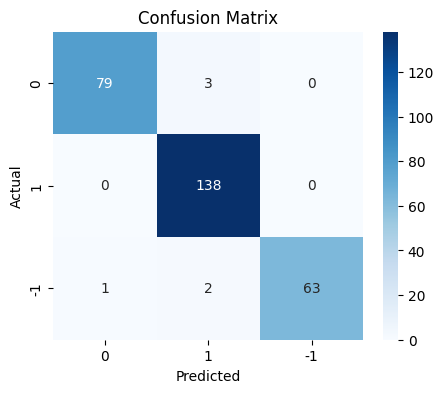

```python
#plot confusion matrix for train data
plot_confusion_matrix(tuned_gl, X_train_gl, y_train)
```

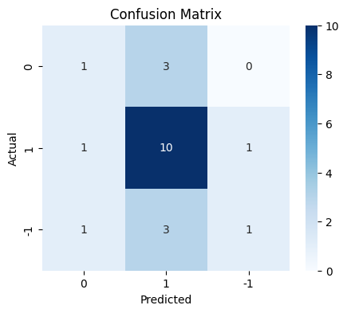

```python
#plot confusion matrix for validation data
plot_confusion_matrix(tuned_gl, X_val_gl, y_val)
```

```python
#calculate metrics for train data
tuned_train_gl = model_performance_classification_sklearn(tuned_gl, X_train_gl, y_train)
tuned_train_gl
```

|  | Accuracy | Recall | Precision | F1 |
| --- | --- | --- | --- | --- |
| 0 | 0.979021 | 0.979021 | 0.979545 | 0.978968 |

```python
#calculate metrics for validation data
tuned_val_gl = model_performance_classification_sklearn(tuned_gl, X_val_gl, y_val)
tuned_val_gl
```

|  | Accuracy | Recall | Precision | F1 |
| --- | --- | --- | --- | --- |
| 0 | 0.571429 | 0.571429 | 0.539683 | 0.530612 |

### Tuned Random Forest - Sentence Transformer

```python
#tune Random Forest Classifier
tuned_st = RandomForestClassifier(random_state=42)
parameters = {
    'max_depth': np.arange(3,7),
    'min_samples_split': np.arange(5,12,2),
    'max_features': ['log2', 'sqrt', 0.2, 0.4]
}
# Run the grid search
grid_obj = GridSearchCV(tuned_st, parameters, scoring='f1_weighted',cv=5,n_jobs=-1)
grid_obj = grid_obj.fit(X_train_st, y_train)

end = time.time()
print("Time taken ",(end-start))

# Set the clf to the best combination of parameters
tuned_st = grid_obj.best_estimator_
```

```
Time taken  484.39644384384155
```

```python
#fit the model
tuned_st.fit(X_train_st, y_train)
```

```
RandomForestClassifier(max_depth=5, max_features=0.4, min_samples_split=9,
                       random_state=42)
```

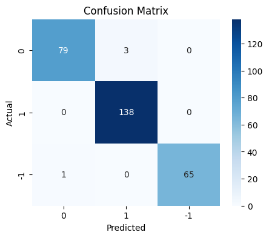

```python
#plot the confusion matrix
plot_confusion_matrix(tuned_st, X_train_st, y_train)
```

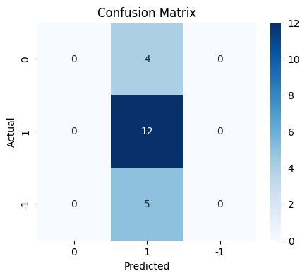

```python
#plot confusion matrix on validation data
plot_confusion_matrix(tuned_st, X_val_st, y_val)
```

```python
#calculate metrics for train data
tuned_train_st = model_performance_classification_sklearn(tuned_st, X_train_st, y_train)
tuned_train_st
```

|  | Accuracy | Recall | Precision | F1 |
| --- | --- | --- | --- | --- |
| 0 | 0.986014 | 0.986014 | 0.98615 | 0.985971 |

```python
#calculate metrics for validation data
tuned_val_st = model_performance_classification_sklearn(tuned_st, X_val_st, y_val)
tuned_val_st
```

|  | Accuracy | Recall | Precision | F1 |
| --- | --- | --- | --- | --- |
| 0 | 0.571429 | 0.571429 | 0.326531 | 0.415584 |

## Model Comparison and Final Model Selection

```python
#training performance comparison

models_train_comp_df = pd.concat(
    [base_train_wv.T,
     base_train_gl.T,
     base_train_st.T,
     tuned_train_wv.T,
     tuned_train_gl.T,
     tuned_train_st.T,
    ],axis=1
)

models_train_comp_df.columns = [
    "Base Model (Word2Vec)",
    "Base Model (GloVe)",
    "Base Model (Sentence Transformer)",
    "Tuned Model (Word2Vec)",
    "Tuned Model (GloVe)",
    "Tuned Model (Sentence Transformer)",
]

print("Training performance comparison:")
models_train_comp_df
```

```
Training performance comparison:
```

|  | Base Model (Word2Vec) | Base Model (GloVe) | Base Model (Sentence Transformer) | Tuned Model (Word2Vec) | Tuned Model (GloVe) | Tuned Model (Sentence Transformer) |
| --- | --- | --- | --- | --- | --- | --- |
| Accuracy | 1.0 | 1.0 | 1.0 | 0.919580 | 0.979021 | 0.986014 |
| Recall | 1.0 | 1.0 | 1.0 | 0.919580 | 0.979021 | 0.986014 |
| Precision | 1.0 | 1.0 | 1.0 | 0.927751 | 0.979545 | 0.986150 |
| F1 | 1.0 | 1.0 | 1.0 | 0.917976 | 0.978968 | 0.985971 |

```python
#validation performance comparison

models_val_comp_df = pd.concat(
    [base_val_wv.T,
     base_val_gl.T,
     base_val_st.T,
     tuned_val_wv.T,
     tuned_val_gl.T,
     tuned_val_st.T,
     ],axis=1
)

models_val_comp_df.columns = [
    "Base Model (Word2Vec)",
    "Base Model (GloVe)",
    "Base Model (Sentence Transformer)",
    "Tuned Model (Word2Vec)",
    "Tuned Model (GloVe)",
    "Tuned Model (Sentence Transformer)",
]

print("Validation performance comparison:")
models_val_comp_df
```

```
Validation performance comparison:
```

|  | Base Model (Word2Vec) | Base Model (GloVe) | Base Model (Sentence Transformer) | Tuned Model (Word2Vec) | Tuned Model (GloVe) | Tuned Model (Sentence Transformer) |
| --- | --- | --- | --- | --- | --- | --- |
| Accuracy | 0.380952 | 0.476190 | 0.523810 | 0.523810 | 0.571429 | 0.571429 |
| Recall | 0.380952 | 0.476190 | 0.523810 | 0.523810 | 0.571429 | 0.571429 |
| Precision | 0.326531 | 0.400794 | 0.314286 | 0.314286 | 0.539683 | 0.326531 |
| F1 | 0.351648 | 0.426871 | 0.392857 | 0.392857 | 0.530612 | 0.415584 |

Observation : Best metrics value is rendered by the Tuned Model on GloVe embedded data.

It has an Accuracy and Recall of 57% , Precion and F1 score of 53% on validation data

We will select this model as our Final model

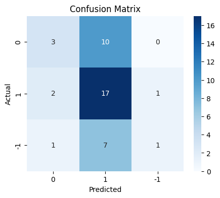

```python
#Tuned Glove model confusion matrix on test data
plot_confusion_matrix(tuned_gl, X_test_gl, y_test)
```

```python
#Caluclate metrics on test data with tuned GloVe model
tuned_test_gl = model_performance_classification_sklearn(tuned_gl, X_test_gl, y_test)
tuned_test_gl
```

|  | Accuracy | Recall | Precision | F1 |
| --- | --- | --- | --- | --- |
| 0 | 0.5 | 0.5 | 0.5 | 0.436529 |

We can see that the Test data has given an Accuracy, Recall and Precision of 50%

The F1 score is 43.7 % which is the best we could get with the model we have tried so far.

## **Weekly News Summarization**

**Important Note**: It is recommended to run this section of the project independently from the previous sections in order to avoid runtime crashes due to RAM overload.

#### Installing and Importing the necessary libraries

```python
# Installation for GPU llama-cpp-python
# uncomment and run the following code in case GPU is being used
!CMAKE_ARGS="-DLLAMA_CUBLAS=on" FORCE_CMAKE=1 pip install llama-cpp-python==0.1.85 --force-reinstall --no-cache-dir -q

# Installation for CPU llama-cpp-python
# uncomment and run the following code in case GPU is not being used
#!CMAKE_ARGS="-DLLAMA_CUBLAS=off" FORCE_CMAKE=1 pip install llama-cpp-python -q
```

[output not shown]

```python
# Function to download the model from the Hugging Face model hub
from huggingface_hub import hf_hub_download

# Importing the Llama class from the llama_cpp module
from llama_cpp import Llama

# Importing the library for data manipulation
import pandas as pd

from tqdm import tqdm # For progress bar related functionalities
tqdm.pandas()
```

#### Loading the data

```python
from google.colab import drive
drive.mount('/content/drive')
```

```python
news = pd.read_csv("/content/drive/MyDrive/NLP Project/stock_news.csv")
```

```python
data1 = news.copy()
```

#### Loading the model

```python
model_name_or_path = "TheBloke/Llama-2-13B-chat-GGUF"
model_basename = "llama-2-13b-chat.Q5_K_M.gguf" # the model is in gguf format
```

```python
# Using hf_hub_download to download a model from the Hugging Face model hub
# The repo_id parameter specifies the model name or path in the Hugging Face repository
# The filename parameter specifies the name of the file to download
model_path = hf_hub_download(
    repo_id=model_name_or_path,
    filename=model_basename
)
```

```python
lcpp_llm = Llama(
    model_path=model_path,
    n_threads=2,  # CPU cores
    n_batch=512,  # Should be between 1 and n_ctx, consider the amount of VRAM in your GPU.
    n_gpu_layers=43,  # Change this value based on your model and your GPU VRAM pool.
    n_ctx=4500,  # Context window
)
```

```
AVX = 1 | AVX2 = 1 | AVX512 = 0 | AVX512_VBMI = 0 | AVX512_VNNI = 0 | FMA = 1 | NEON = 0 | ARM_FMA = 0 | F16C = 1 | FP16_VA = 0 | WASM_SIMD = 0 | BLAS = 1 | SSE3 = 1 | SSSE3 = 1 | VSX = 0 |
```

#### Aggregating the data weekly

```python
data1["Date"] = pd.to_datetime(data1['Date'])  # Convert the 'Date' column to datetime format.
```

```python
# Group the data by week using the 'Date' column.
weekly_grouped = data1.groupby(pd.Grouper(key='Date', freq='W'))
```

```python
weekly_grouped = weekly_grouped.agg(
    {
        'News': lambda x: ' || '.join(x)  # Join the news values with ' || ' separator.
    }
).reset_index()

print(weekly_grouped.shape)
```

```
(18, 2)
```

```python
weekly_grouped
```

|  | Date | News |
| --- | --- | --- |
| 0 | 2019-01-06 | The tech sector experienced a significant dec... |
| 1 | 2019-01-13 | Sprint and Samsung plan to release 5G smartph... |
| 2 | 2019-01-20 | The U.S. stock market declined on Monday as c... |
| 3 | 2019-01-27 | The Swiss National Bank (SNB) governor, Andre... |
| 4 | 2019-02-03 | Caterpillar Inc reported lower-than-expected ... |
| 5 | 2019-02-10 | The Dow Jones Industrial Average, S&P 500, an... |
| 6 | 2019-02-17 | This week, the European Union's second highes... |
| 7 | 2019-02-24 | This news article discusses progress towards ... |
| 8 | 2019-03-03 | The Dow Jones Industrial Average and other ma... |
| 9 | 2019-03-10 | Spotify, the world's largest paid music strea... |
| 10 | 2019-03-17 | The United States opposes France's digital se... |
| 11 | 2019-03-24 | Facebook's stock price dropped more than 3% o... |
| 12 | 2019-03-31 | This news article reports that the S&P 500 In... |
| 13 | 2019-04-07 | Apple and other consumer brands, including LV... |
| 14 | 2019-04-14 | In March, mobile phone shipments to China dro... |
| 15 | 2019-04-21 | The chairman of Taiwan's Foxconn, Terry Gou, ... |
| 16 | 2019-04-28 | Taiwan's export orders continued to decline f... |
| 17 | 2019-05-05 | Spotify reported better-than-expected Q1 reve... |

```python
# creating a copy of the data
data_1 = weekly_grouped.copy()
```

#### Summarization

**Note**:

- The model is expected to summarize the news from the week by identifying the top three positive and negative events that are most likely to impact the price of the stock.
- As an output, the model is expected to return a JSON containing two keys, one for Positive Events and one for Negative Events.

For the project, we need to define the prompt to be fed to the LLM to help it understand the task to perform. The following should be the components of the prompt:

1. **Role**: Specifies the role the LLM will be taking up to perform the specified task, along with any specific details regarding the role
   - **Example**: `You are an expert data analyst specializing in news content analysis.`
2. **Task**: Specifies the task to be performed and outlines what needs to be accomplished, clearly defining the objective
   - **Example**: `Analyze the provided news headline and return the main topics contained within it.`
3. **Instructions**: Provides detailed guidelines on how to perform the task, which includes steps, rules, and criteria to ensure the task is executed correctly
   - **Example**:

```
Instructions:
1. Read the news headline carefully.
2. Identify the main subjects or entities mentioned in the headline.
3. Determine the key events or actions described in the headline.
4. Extract relevant keywords that represent the topics.
5. List the topics in a concise manner.
```

1. **Output Format**: Specifies the format in which the final response should be structured, ensuring consistency and clarity in the generated output
   - **Example**: `Return the output in JSON format with keys as the topic number and values as the actual topic.`

**Full Prompt Example**:

```
You are an expert data analyst specializing in news content analysis.

Task: Analyze the provided news headline and return the main topics contained within it.

Instructions:
1. Read the news headline carefully.
2. Identify the main subjects or entities mentioned in the headline.
3. Determine the key events or actions described in the headline.
4. Extract relevant keywords that represent the topics.
5. List the topics in a concise manner.

Return the output in JSON format with keys as the topic number and values as the actual topic.
```

**Sample Output**:

`{"1": "Politics", "2": "Economy", "3": "Health" }`

##### Utility Functions

```python
# defining a function to parse the JSON output from the model
def extract_json_data(json_str):
    import json
    try:
        # Find the indices of the opening and closing curly braces
        json_start = json_str.find('{')
        json_end = json_str.rfind('}')

        if json_start != -1 and json_end != -1:
            extracted_category = json_str[json_start:json_end + 1]  # Extract the JSON object
            data_dict = json.loads(extracted_category)
            return data_dict
        else:
            print(f"Warning: JSON object not found in response: {json_str}")
            return {}
    except json.JSONDecodeError as e:
        print(f"Error parsing JSON: {e}")
        return {}
```

```python
def extract_json_data_array(json_str):
    try:
        # Check for the opening of an array or object
        json_start_object = json_str.find('{')
        json_start_array = json_str.find('[')

        # If both are found, take the earliest start (either for an object or an array)
        if json_start_object == -1 and json_start_array == -1:
            print(f"Warning: No JSON object or array found in response: {json_str}")
            return {}

        # Prioritize the earlier start (either array or object)
        json_start = min(filter(lambda x: x != -1, [json_start_object, json_start_array]))

        # Check if it's an array or object by looking for the corresponding closing bracket
        if json_str[json_start] == '{':
            json_end = json_str.rfind('}')
        elif json_str[json_start] == '[':
            json_end = json_str.rfind(']')

        if json_start != -1 and json_end != -1:
            extracted_json = json_str[json_start:json_end + 1]  # Extract the JSON (either object or array)
            data = json.loads(extracted_json)  # Parse the JSON string
            return data
        else:
            print(f"Warning: JSON object or array not found in response: {json_str}")
            return {}
    except json.JSONDecodeError as e:
        print(f"Error parsing JSON: {e}")
        return {}
```

##### Defining the response function

```python
def generate_llama_response(instruction, review):

    # System message explicitly instructing not to include the review text
    system_message = """
        [INST]<<SYS>>
        {}
        <</SYS>>[/INST]
    """.format(instruction)

    # Combine user_prompt and system_message to create the prompt
    prompt = f"{review}\n{system_message}"

    # Generate a response from the LLaMA model
    response = lcpp_llm(
        prompt=prompt,
        max_tokens=1024,
        temperature=0,
        top_p=0.95,
        repeat_penalty=1.2,
        top_k=50,
        stop=['INST'],
        echo=False,

    )

    # Extract the sentiment from the response
    response_text = response["choices"][0]["text"]
    return response_text
```

##### Checking the model output on a sample

**Note**: Use this section to test out the prompt with one instance before using it for the entire weekly data.

```python
# defining the instructions for the model
instruction = """
You are an expert data analyst specializing in news content analysis.

Task: Analyze the provided news headline and return the main topics contained within it.

Instructions:
1. Read the news headline carefully.
2. Identify the main subjects or entities mentioned in the headline.
3. Determine the key events or actions described in the headline.
4. Extract relevant keywords that represent the topics.
5. List the topics in a concise manner.

Return Only the output in JSON containing two keys, one for Positive Events and one for Negative Events. Limit number of topics to maximum 3.Summarize topic in 3 words. Format as shown below:
{"Positive Events": "Topic1", "Negative Events": "Topic2"}
"""
"""
"""
```

```
'\n'
```

```python
data_1["News"][0]
```

```
' The tech sector experienced a significant decline in the aftermarket following Apple\'s Q1 revenue warning. Notable suppliers, including Skyworks, Broadcom, Lumentum, Qorvo, and TSMC, saw their stocks drop in response to Apple\'s downward revision of its revenue expectations for the quarter, previ…
```

```python
response = generate_llama_response(instruction, data_1["News"][0])
print(response)
```

```
Llama.generate: prefix-match hit
```

```
 {
       "Positive Events": "Apple's revenue warning",
       "Negative Events": "Global economic slowdown"
      }
```

```python
response = extract_json_data_array(response)
response
```

```
{'Positive Events': "Apple's revenue warning",
 'Negative Events': 'Global economic slowdown'}
```

```python
data_1['model_response'] = data_1['News'].apply(lambda x: generate_llama_response(instruction, x))
```

[output not shown]

```python
#check the first row of the reponse and data
data_1['model_response'][1]
```

```
' Sure, I\'d be happy to help! Here is the analysis of the provided news headline:\n\nHeadline: Sprint and Samsung plan to release 5G smartphones in nine U.S. cities this summer, with Atlanta, Chicago, Dallas, Houston, Kansas City, Los Angeles, New York City, Phoenix, and Washington D.C. being the i…
```

##### Checking the model output on the weekly data

```python
# replace \n
data_1['model_response'] = data_1['model_response'].apply(lambda x: x.replace('\n', ''))
```

```python
#check the first row of the reponse and data
data_1['model_response'][1]
```

```
' Sure, I\'d be happy to help! Here is the analysis of the provided news headline:Headline: Sprint and Samsung plan to release 5G smartphones in nine U.S. cities this summer, with Atlanta, Chicago, Dallas, Houston, Kansas City, Los Angeles, New York City, Phoenix, and Washington D.C. being the initi…
```

```python
# check top 5 model response
data_1['model_response'].head()
```

|  | model_response |
| --- | --- |
| 0 | { "Positive Events": "Apple's revenue w... |
| 1 | Sure, I'd be happy to help! Here is the analy... |
| 2 | Sure, I'd be happy to help! Here is the analy... |
| 3 | Sure, I'd be happy to help! Here is the analy... |
| 4 | Sure, I'd be happy to help! Here is the analy... |

**dtype:** object

```python
data_1['model_response'][1]
```

```
' Sure, I\'d be happy to help! Here is the analysis of the provided news headline:Headline: Sprint and Samsung plan to release 5G smartphones in nine U.S. cities this summer, with Atlanta, Chicago, Dallas, Houston, Kansas City, Los Angeles, New York City, Phoenix, and Washington D.C. being the initi…
```

##### Formatting the model output

```python
data_1['model_response_parsed'] = data_1['model_response'].apply(extract_json_data)
data_1.head()
```

|  | Date | News | model_response | model_response_parsed |
| --- | --- | --- | --- | --- |
| 0 | 2019-01-06 | The tech sector experienced a significant dec... | { "Positive Events": "Apple's revenue w... | {'Positive Events': 'Apple's revenue warning',... |
| 1 | 2019-01-13 | Sprint and Samsung plan to release 5G smartph... | Sure, I'd be happy to help! Here is the analy... | {'Positive Events': '5G Rollout', 'Negative Ev... |
| 2 | 2019-01-20 | The U.S. stock market declined on Monday as c... | Sure, I'd be happy to help! Here is the analy... | {'Negative Events': 'Economic Slowdown, Weak i... |
| 3 | 2019-01-27 | The Swiss National Bank (SNB) governor, Andre... | Sure, I'd be happy to help! Here is the analy... | {'Positive Events': 'Local Manufacturing', 'Ne... |
| 4 | 2019-02-03 | Caterpillar Inc reported lower-than-expected ... | Sure, I'd be happy to help! Here is the analy... | {} |

```python
model_response_parsed = pd.json_normalize(data_1['model_response_parsed'])
model_response_parsed.head()
```

|  | Positive Events | Negative Events |
| --- | --- | --- |
| 0 | Apple's revenue warning | Global economic slowdown |
| 1 | 5G Rollout | None |
| 2 | NaN | Economic Slowdown, Weak iPhone Sales |
| 3 | Local Manufacturing | Challenges for Apple and Samsung |
| 4 | NaN | NaN |

```python
model_response_parsed.shape
```

```
(18, 2)
```

```python
# check is Positive Events is string
model_response_parsed['Positive Events'].apply(type).value_counts()
```

| Positive Events | count |
| --- | --- |
| <class 'str'> | 12 |
| <class 'float'> | 4 |
| <class 'NoneType'> | 2 |

**dtype:** int64

```python
# convert data from list to string in Positive Events and Negative Events. join
for col in ['Positive Events', 'Negative Events']:
    model_response_parsed[col] = model_response_parsed[col].apply(lambda x: ','.join(x) if isinstance(x, list) else x)
```

```python
final_output = pd.concat([data_1.reset_index(drop=True),model_response_parsed],axis=1)
final_output.drop(['model_response','model_response_parsed'], axis=1, inplace=True)
final_output.columns = ['Week End Date', 'News', 'Week Positive Events', 'Week Negative Events']
```

```python
final_output.head(18)
```

|  | Week End Date | News | Week Positive Events | Week Negative Events |
| --- | --- | --- | --- | --- |
| 0 | 2019-01-06 | The tech sector experienced a significant dec... | Apple's revenue warning | Global economic slowdown |
| 1 | 2019-01-13 | Sprint and Samsung plan to release 5G smartph... | 5G Rollout | None |
| 2 | 2019-01-20 | The U.S. stock market declined on Monday as c... | NaN | Economic Slowdown, Weak iPhone Sales |
| 3 | 2019-01-27 | The Swiss National Bank (SNB) governor, Andre... | Local Manufacturing | Challenges for Apple and Samsung |
| 4 | 2019-02-03 | Caterpillar Inc reported lower-than-expected ... | NaN | NaN |
| 5 | 2019-02-10 | The Dow Jones Industrial Average, S&P 500, an... | Tech Stocks Rise | None |
| 6 | 2019-02-17 | This week, the European Union's second highes... | Self-Driving Car Development | Lack of Progress |
| 7 | 2019-02-24 | This news article discusses progress towards ... | Garmin's Strong Earnings | Kraft Heinz Under SEC Investigation |
| 8 | 2019-03-03 | The Dow Jones Industrial Average and other ma... | Trade Talks Progress | Delayed Tariff Hikes |
| 9 | 2019-03-10 | Spotify, the world's largest paid music strea... | NaN | NaN |
| 10 | 2019-03-17 | The United States opposes France's digital se... | None | Apple-Spotify Dispute |
| 11 | 2019-03-24 | Facebook's stock price dropped more than 3% o... | Tech Stocks Rebound | NaN |
| 12 | 2019-03-31 | This news article reports that the S&P 500 In... | Streaming | Economic Uncertainty |
| 13 | 2019-04-07 | Apple and other consumer brands, including LV... | NaN | NaN |
| 14 | 2019-04-14 | In March, mobile phone shipments to China dro... | Partnership between Prince Harry and Oprah Win... | Slowing sales of Apple products in China |
| 15 | 2019-04-21 | The chairman of Taiwan's Foxconn, Terry Gou, ... | Innovation | None |
| 16 | 2019-04-28 | Taiwan's export orders continued to decline f... | None | Decline in Taiwan's export orders, delay of Ga... |
| 17 | 2019-05-05 | Spotify reported better-than-expected Q1 reve... | Spotify's revenue growth |  |

## **Conclusions and Recommendations**

### Tasks Accomplished for Setiment Analysis :

- We did a data Overview and Exploratory Data Analysis to plot and infer the paarmeters that can affect the Setiment
- We embedded the words using Word2Vec, GloVe and Sentence Transformer.
- We build base model with Random Forest for 3 sets of data. Calculated the performance in each.
- Then we tuned the model and fitted the 3 sets of data and again colelcting the performace metrics.

#### We identified the Tuned Random Forest gives the best Performace and hence selected this as our final Model for Setiment Analysis.

### Tasks Accomplished for Summarization

- We used Llam Model for summarization
- We split the news data in to weekly News
- We used Prompts to send instructions and the News data to the model and used instruction to summarize the data as Positive and Negative Setiments. We also used promptto inform the model to send us the data in json format.
- We parsed the json output recieved from the model and created a dataframe with Date, News, Positive and Negative Setiments column and presented it for lookup.

The organization can leverage sentiment categorizations to tailor marketing strategies.

Highlighting positive sentiments in promotional material can contribute to a positive brand image. They can use neutral and negative sentiments to make informed decisions around inventory.

-

Power Ahead